# Week 4 Exercises

```r
library(tidyverse)
```

# Exercise 1

Read the region_scores.csv data.

```r
# read "region_scores.csv"data
list.files('C:/Users/eliyuan/Documents/GitHub')
```

```
[1] "datavis-R-2021"
[2] "datavis-R-2022"
[3] "datavis-R-2023"
[4] "datavis-R-2024"
[5] "datavis-R-2026"
[6] "datavis-R-2027"
[7] "https---github.com-Liyuan202-IODS-project.git"
[8] "IODS-project"
[9] "新建文件夹"
```

```r
df <- readr::read_csv('data/region_scores.csv')
df
```

| id | region | education | gender | age | score |
| --- | --- | --- | --- | --- | --- |
| 1 | South Karelia | 1 | M | 56 | 4.268811 |
| 2 | Satakunta | 1 | F | 41 | 5.646586 |
| 3 | Kymenlaakso | 1 | M | 48 | 6.949019 |
| 4 | South Karelia | 1 | F | 41 | 7.096777 |
| 5 | Southern Ostrobothnia | 1 | F | 35 | 6.990985 |
| 6 | Uusimaa | 1 | F | 60 | 5.267663 |
| 7 | Kymenlaakso | 1 | M | 28 | 8.448429 |
| 8 | Uusimaa | 1 | F | 28 | 4.708063 |
| 9 | Kainuu | 1 | M | 48 | 8.506398 |
| 10 | Southern Savonia | 1 | M | 51 | 7.494451 |

[output cut: 230 more lines]

Create a figure that shows the distributions (e.g. density plot, histogram) of **age** and **score** in separate subplots (facets). What do you need to do first?

In the figure, set individual x-axis limits for age and score by modifying the `scales` parameter within `facet_wrap()`.

**Hint**: To make things simpler, you can begin by selecting only the variables you need here, i.e. age and score.

```r
df_long <- df %>%
  gather(age, score, -id, -region, -education, -gender)
df_long
```

| id | region | education | gender | age | score |
| --- | --- | --- | --- | --- | --- |
| 1 | South Karelia | 1 | M | age | 56.000000 |
| 2 | Satakunta | 1 | F | age | 41.000000 |
| 3 | Kymenlaakso | 1 | M | age | 48.000000 |
| 4 | South Karelia | 1 | F | age | 41.000000 |
| 5 | Southern Ostrobothnia | 1 | F | age | 35.000000 |
| 6 | Uusimaa | 1 | F | age | 60.000000 |
| 7 | Kymenlaakso | 1 | M | age | 28.000000 |
| 8 | Uusimaa | 1 | F | age | 28.000000 |
| 9 | Kainuu | 1 | M | age | 48.000000 |
| 10 | Southern Savonia | 1 | M | age | 51.000000 |

[output cut: 470 more lines]

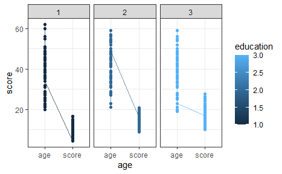

```r
df_long %>%
  ggplot(aes(age, score, group = education, colour = education)) +
  geom_line(alpha=.7) +
  geom_point() +
  facet_wrap(~education) + theme_bw()
```

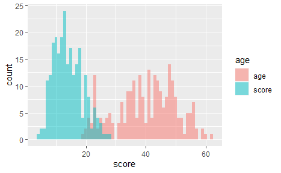

```r
df_long %>%
  ggplot(aes(score, fill = age)) +
  geom_histogram(position = "identity", alpha = .5, binwidth = 1)
```

# Exercise 2

In this exercise, you will use the built-in iris dataset.

```r
head(iris)
```

|  | Sepal.Length | Sepal.Width | Petal.Length | Petal.Width | Species |
| --- | --- | --- | --- | --- | --- |
| 1 | 5.1 | 3.5 | 1.4 | 0.2 | setosa |
| 2 | 4.9 | 3.0 | 1.4 | 0.2 | setosa |
| 3 | 4.7 | 3.2 | 1.3 | 0.2 | setosa |
| 4 | 4.6 | 3.1 | 1.5 | 0.2 | setosa |
| 5 | 5.0 | 3.6 | 1.4 | 0.2 | setosa |
| 6 | 5.4 | 3.9 | 1.7 | 0.4 | setosa |

#### 2.1

Make the data into long format: gather all variables except species into new variables **var** (variable names) and **measure** (numerical values). You should end up with 600 rows and 3 columns (Species, var, and measure). Assign the result into `iris_long`.

```r
iris_long <- iris %>%
  gather(var, measure, -Species)
iris_long
```

| Species | var | measure |
| --- | --- | --- |
| setosa | Sepal.Length | 5.1 |
| setosa | Sepal.Length | 4.9 |
| setosa | Sepal.Length | 4.7 |
| setosa | Sepal.Length | 4.6 |
| setosa | Sepal.Length | 5.0 |
| setosa | Sepal.Length | 5.4 |
| setosa | Sepal.Length | 4.6 |
| setosa | Sepal.Length | 5.0 |
| setosa | Sepal.Length | 4.4 |
| setosa | Sepal.Length | 4.9 |

[output cut: 590 more lines]

#### 2.2

In `iris_long`, separate **var** into two variables: **part** (Sepal/Petal values) and **dim** (Length/Width).

Then, spread the measurement values to new columns that get their names from **dim**. You must create row numbers by dim group before doing this.

You should now have 300 rows of variables Species, part, Length and Width (and row numbers). Assign the result into `iris_wide`.

```r
iris_long <- iris_long %>%
  separate(var, into = c('part', 'dim'), convert = TRUE)
iris_wide <- iris_long %>%
   group_by(dim) %>%
  mutate(row = row_number()) %>%
  ungroup %>%
  spread(dim, measure) %>%
  select(-row)
iris_wide
```

| Species | part | Length | Width |
| --- | --- | --- | --- |
| setosa | Petal | 1.4 | 0.2 |
| setosa | Petal | 1.4 | 0.2 |
| setosa | Petal | 1.3 | 0.2 |
| setosa | Petal | 1.5 | 0.2 |
| setosa | Petal | 1.4 | 0.2 |
| setosa | Petal | 1.7 | 0.4 |
| setosa | Petal | 1.4 | 0.3 |
| setosa | Petal | 1.5 | 0.2 |
| setosa | Petal | 1.4 | 0.2 |
| setosa | Petal | 1.5 | 0.1 |

[output cut: 290 more lines]

#### 2.3

Using `iris_wide`, plot a scatter plot of length on the x-axis and width on the y-axis. Colour the points by part.

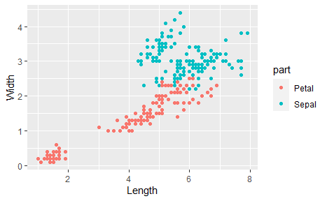

```r
iris_wide %>%
  ggplot(aes(x = Length, y = Width, color = part)) +
  geom_point()
```

# Working with your own data

In exercises 3-5, you’ll work with your own dataset. **If you don’t have you own data, use the fss_learning.csv data (see description below).**

In these exercises, you are required to provide an overview of your data, using the tools we have learned so far. Because all datasets are different, the format of the exercises is quite open. You will get points for being thorough and trying your best - even if you didn’t know how to write something in code, be explicit with what you were **trying** to achieve. When submitting the exercises, **please return both an .Rmd and an .html file! The HTML file created by previewing a Notebook (with the suffix .nb.html) is fine, but make sure that the HTML contains all the code and output that is needed for getting an impression of the data. In other words, the document needs to be readable without having access to the full dataset.**

#### the fss_learning data

fss_learning.csv contains data from a longitudinal skill learning experiment. There are observations at multiple levels: a total of 18 **participants**, each completing 8 **sessions** which consist of 5 **runs** (trials) of a game-like driving task (i.e. 8*5 = 40 trials per participant). You can read more about the design [here](https://doi.org/10.3389/fpsyg.2019.01126).

In the data, there are trial-level measures related to performance (number of **collisions**, **duration** in seconds, **distance** travelled), as well as self-reports on a scale of 1-7 (variables fluency:comp3) collected after each trial or session.

# Exercise 3

#### 3.1

Import your data into R. Check that you have the correct number of rows and columns, column names are in place, the encoding of characters looks OK, etc.

```r
list.files('C:/Users/eliyuan/Documents/GitHub')
```

```
[1] "datavis-R-2021"
[2] "datavis-R-2022"
[3] "datavis-R-2023"
[4] "datavis-R-2024"
[5] "datavis-R-2026"
[6] "datavis-R-2027"
[7] "https---github.com-Liyuan202-IODS-project.git"
[8] "IODS-project"
[9] "新建文件夹"
```

```r
fss <- readr::read_csv('data/fss_learning.csv')
```

#### 3.2

Print the structure/glimpse/summary of the data. Outline briefly what kind of variables you have and if there are any missing or abnormal values. Make sure that each variable has the right class (numeric/character/factor etc).

```r
fss
```

| participant | gender | session | run | collisions | duration | distance | cumrun | fluency | absorption | flow | pi1 | pi2 | pi3 | comp1 | comp2 | comp3 |
| --- | --- | --- | --- | --- | --- | --- | --- | --- | --- | --- | --- | --- | --- | --- | --- | --- |
| 1 | male | 1 | 1 | 26 | 233.6105 | 24196.57 | 1 | 4.75 | 6.0 | 5.444444 | 5 | 2 | 3 | NA | NA | NA |
| 1 | male | 1 | 2 | 30 | 204.8506 | 24197.47 | 2 | 4.50 | 4.6 | 4.555556 | 3 | 2 | 2 | NA | NA | NA |
| 1 | male | 1 | 3 | 20 | 190.1887 | 24199.04 | 3 | 5.25 | 5.4 | 5.333333 | 5 | 3 | 2 | NA | NA | NA |
| 1 | male | 1 | 4 | 13 | 181.4123 | 24197.93 | 4 | 5.00 | 5.0 | 5.000000 | 4 | 3 | 2 | NA | NA | NA |
| 1 | male | 1 | 5 | 18 | 188.9267 | 24197.89 | 5 | 4.25 | 4.6 | 4.444444 | 4 | 3 | 2 | 3 | 5 | 4 |
| 1 | male | 2 | 1 | 18 | 184.5798 | 24197.58 | 6 | 4.00 | 4.8 | 4.444444 | 3 | 3 | 3 | NA | NA | NA |
| 1 | male | 2 | 2 | 21 | 173.1695 | 24196.49 | 7 | 5.50 | 5.6 | 5.555556 | 4 | 4 | 3 | NA | NA | NA |
| 1 | male | 2 | 3 | 20 | 187.3442 | 24196.84 | 8 | 4.00 | 5.0 | 4.555556 | 4 | 3 | 3 | NA | NA | NA |
| 1 | male | 2 | 4 | 15 | 173.9570 | 24197.68 | 9 | 5.00 | 5.8 | 5.444444 | 5 | 3 | 2 | NA | NA | NA |
| 1 | male | 2 | 5 | 15 | 197.1904 | 24198.82 | 10 | 3.75 | 4.2 | 4.000000 | 3 | 3 | 3 | 3 | 5 | 4 |

[output cut: 710 more lines]

```r
str(fss)
```

```
spec_tbl_df [720 x 17] (S3: spec_tbl_df/tbl_df/tbl/data.frame)
 $ participant: Factor w/ 18 levels "1","2","3","4",..: 1 1 1 1 1 1 1 1 1 1 ...
 $ gender     : chr [1:720] "male" "male" "male" "male" ...
 $ session    : num [1:720] 1 1 1 1 1 2 2 2 2 2 ...
 $ run        : num [1:720] 1 2 3 4 5 1 2 3 4 5 ...
 $ collisions : num [1:720] 26 30 20 13 18 18 21 20 15 15 ...
 $ duration   : num [1:720] 234 205 190 181 189 ...
 $ distance   : num [1:720] 24197 24197 24199 24198 24198 ...
 $ cumrun     : num [1:720] 1 2 3 4 5 6 7 8 9 10 ...
 $ fluency    : num [1:720] 4.75 4.5 5.25 5 4.25 4 5.5 4 5 3.75 ...
 $ absorption : num [1:720] 6 4.6 5.4 5 4.6 4.8 5.6 5 5.8 4.2 ...
 $ flow       : num [1:720] 5.44 4.56 5.33 5 4.44 ...
 $ pi1        : num [1:720] 5 3 5 4 4 3 4 4 5 3 ...
 $ pi2        : num [1:720] 2 2 3 3 3 3 4 3 3 3 ...
 $ pi3        : num [1:720] 3 2 2 2 2 3 3 3 2 3 ...
 $ comp1      : num [1:720] NA NA NA NA 3 NA NA NA NA 3 ...
 $ comp2      : num [1:720] NA NA NA NA 5 NA NA NA NA 5 ...
 $ comp3      : num [1:720] NA NA NA NA 4 NA NA NA NA 4 ...
 - attr(*, "spec")=
  .. cols(
  ..   participant = col_double(),
  ..   gender = col_character(),
  ..   session = col_double(),
  ..   run = col_double(),
  ..   collisions = col_double(),
  ..   duration = col_double(),
  ..   distance = col_double(),
  ..   cumrun = col_double(),
  ..   fluency = col_double(),
  ..   absorption = col_double(),
  ..   flow = col_double(),
  ..   pi1 = col_double(),
  ..   pi2 = col_double(),
  ..   pi3 = col_double(),
  ..   comp1 = col_double(),
  ..   comp2 = col_double(),
  ..   comp3 = col_double()
  .. )
```

```r
summary(fss)
```

```
  participant     gender             session
 1      : 40   Length:720         Min.   :1.00
 2      : 40   Class :character   1st Qu.:2.75
 3      : 40   Mode  :character   Median :4.50
 4      : 40                      Mean   :4.50
 5      : 40                      3rd Qu.:6.25
 6      : 40                      Max.   :8.00
 (Other):480
      run      collisions       duration
 Min.   :1   Min.   : 4.00   Min.   :160.0
 1st Qu.:2   1st Qu.:13.00   1st Qu.:172.5
 Median :3   Median :17.00   Median :181.3
 Mean   :3   Mean   :17.67   Mean   :186.3
 3rd Qu.:4   3rd Qu.:22.00   3rd Qu.:194.7
 Max.   :5   Max.   :43.00   Max.   :413.3
             NA's   :1       NA's   :1
    distance         cumrun         fluency
 Min.   :24196   Min.   : 1.00   Min.   :2.000
 1st Qu.:24197   1st Qu.:10.50   1st Qu.:4.000
 Median :24198   Median :20.00   Median :4.750
 Mean   :24198   Mean   :20.47   Mean   :4.617
 3rd Qu.:24198   3rd Qu.:30.00   3rd Qu.:5.250
 Max.   :24200   Max.   :40.00   Max.   :7.000
 NA's   :1       NA's   :1       NA's   :1
   absorption         flow            pi1
 Min.   :2.400   Min.   :2.444   Min.   :1.000
 1st Qu.:4.700   1st Qu.:4.444   1st Qu.:5.000
 Median :5.200   Median :5.000   Median :6.000
 Mean   :5.248   Mean   :4.968   Mean   :5.328
 3rd Qu.:5.800   3rd Qu.:5.556   3rd Qu.:6.000
 Max.   :7.000   Max.   :7.000   Max.   :7.000
 NA's   :1       NA's   :1       NA's   :1
      pi2             pi3            comp1
 Min.   :1.000   Min.   :1.000   Min.   :1.000
 1st Qu.:2.000   1st Qu.:1.000   1st Qu.:3.000
 Median :4.000   Median :2.000   Median :3.000
 Mean   :3.702   Mean   :2.713   Mean   :3.514
 3rd Qu.:5.000   3rd Qu.:4.000   3rd Qu.:5.000
 Max.   :7.000   Max.   :7.000   Max.   :6.000
 NA's   :1       NA's   :1       NA's   :576
     comp2           comp3
 Min.   :2.000   Min.   :2.000
 1st Qu.:4.000   1st Qu.:4.000
 Median :4.000   Median :4.000
 Mean   :4.264   Mean   :3.993
 3rd Qu.:5.000   3rd Qu.:4.000
 Max.   :6.000   Max.   :6.000
 NA's   :576     NA's   :576
```

```r
glimpse(fss)
```

```
Rows: 720
Columns: 17
$ participant <fct> 1, 1, 1, 1, 1, 1, 1, 1, 1, 1, 1, ~
$ gender      <chr> "male", "male", "male", "male", "~
$ session     <dbl> 1, 1, 1, 1, 1, 2, 2, 2, 2, 2, 3, ~
$ run         <dbl> 1, 2, 3, 4, 5, 1, 2, 3, 4, 5, 1, ~
$ collisions  <dbl> 26, 30, 20, 13, 18, 18, 21, 20, 1~
$ duration    <dbl> 233.6105, 204.8506, 190.1887, 181~
$ distance    <dbl> 24196.57, 24197.47, 24199.04, 241~
$ cumrun      <dbl> 1, 2, 3, 4, 5, 6, 7, 8, 9, 10, 11~
$ fluency     <dbl> 4.75, 4.50, 5.25, 5.00, 4.25, 4.0~
$ absorption  <dbl> 6.0, 4.6, 5.4, 5.0, 4.6, 4.8, 5.6~
$ flow        <dbl> 5.444444, 4.555556, 5.333333, 5.0~
$ pi1         <dbl> 5, 3, 5, 4, 4, 3, 4, 4, 5, 3, 4, ~
$ pi2         <dbl> 2, 2, 3, 3, 3, 3, 4, 3, 3, 3, 3, ~
$ pi3         <dbl> 3, 2, 2, 2, 2, 3, 3, 3, 2, 3, 3, ~
$ comp1       <dbl> NA, NA, NA, NA, 3, NA, NA, NA, NA~
$ comp2       <dbl> NA, NA, NA, NA, 5, NA, NA, NA, NA~
$ comp3       <dbl> NA, NA, NA, NA, 4, NA, NA, NA, NA~
```

```r
# transform "participant" to factor variable
fss <- fss %>%
  mutate(participant = factor(participant))
```

# Exercise 4

Pick a few (2-5) variables of interest from your data (ideally, both categorical and numerical).

For **categorical variables**, count the observations in each category (or combination of categories). Are the frequencies balanced?

```r
fss %>%
  group_by(gender, .drop = FALSE) %>%
  summarise(n = n()) %>%
  ungroup()
```

| gender | n |
| --- | --- |
| female | 320 |
| male | 400 |

```r
# The frequencies of gender seems quite balanced.
```

For **numerical variables**, compute some summary statistics (e.g. min, max, mean, median, SD) over the whole dataset or for subgroups. What can you say about the distributions of these variables, or possible group-wise differences?

```r
fss %>%
  group_by(session, .drop = FALSE) %>%
  summarise(mean_collisions = mean(collisions ),
            sd_collisions  = sd(collisions ),
            min_collisions = min(collisions ),
            max_collisions = max(collisions ),
            median_collisions = median(collisions)) %>%
  ungroup()
```

| session | mean_collisions | sd_collisions | min_collisions | max_collisions | median_collisions |
| --- | --- | --- | --- | --- | --- |
| 1 | 24.01111 | 7.090894 | 11 | 42 | 24.0 |
| 2 | 21.18889 | 6.595699 | 11 | 43 | 21.0 |
| 3 | 18.33333 | 5.941664 | 8 | 35 | 18.0 |
| 4 | 17.02222 | 5.270179 | 7 | 30 | 17.0 |
| 5 | 16.11111 | 5.657737 | 5 | 31 | 15.0 |
| 6 | NA | NA | NA | NA | NA |
| 7 | 14.82222 | 5.387413 | 4 | 32 | 14.5 |
| 8 | 14.41111 | 4.939850 | 4 | 27 | 14.0 |

# Exercise 5

#### 5.1

Describe if there’s anything else you think should be done as “pre-processing” steps (e.g. recoding/grouping values, renaming variables, removing variables or mutating new ones, reshaping the data to long format, merging data frames together).

I am thinking the pi1,pi2,pi3 can be transformed from wide to long format, so as comp1, comp2 and comp3. And session and run can merging.

#### 5.2

Do you have an idea of what kind of relationships in your data you would like to visualise and for which variables? For example, would you like to depict variable distributions, the structure of multilevel data, summary statistics (e.g. means), or include model fits or predictions?

I am not sure about that, I am thinking to leant R in a more general way, since I am not using R as a data analysis software now. Also, I am a beginner, and I do not think that I have the capacity to do the data analysis but may be I will be after attending this course.